# Cleaning Data in R

### Cleaning data

In this part of the training, we will cover

- Tidy and untidy data
- Long and wide data
- Converting long to wide and vice versa
- Unite and separate columns
- String to time conversion
- Working with strings
- Working with missing data

```r
setwd("E:/Training_S/Cleaning Data in R")
data1 = read.csv("retail.csv", header = TRUE,  sep=";", stringsAsFactors=FALSE)
head(data1)
```

```
##   X1.121.200000.Mirpur.6
## 1  1,231,450000,Mirpur 6
## 2  1,544,800000,Mirpur 6
## 3  1,213,400000,Mirpur 6
## 4  1,221,389000,Mirpur 6
## 5  1,214,478900,Mirpur 6
## 6  1,322,750000,Mirpur 6
```

#### Understand your data

```r
class(data1)
```

```
## [1] "data.frame"
```

#### How many rows and columns in the dataset?

```r
dim(data1)
```

```
## [1] 20  1
```

#### Column names?

```r
names(data1)
```

```
## [1] "X1.121.200000.Mirpur.6"
```

#### Understanding our data

```r
str(data1)
```

```
## 'data.frame':    20 obs. of  1 variable:
##  $ X1.121.200000.Mirpur.6: chr  "1,231,450000,Mirpur 6" "1,544,800000,Mirpur 6" "1,213,400000,Mirpur 6" "1,221,389000,Mirpur 6" ...
```

#### We can also use **dplyr** package

```r
library(dplyr)
glimpse(data1)
```

```
## Observations: 20
## Variables: 1
## $ X1.121.200000.Mirpur.6 <chr> "1,231,450000,Mirpur 6", "1,544,800000,...
```

We can also use **summary()** function

```r
summary(data1)
```

```
##  X1.121.200000.Mirpur.6
##  Length:20
##  Class :character
##  Mode  :character
```

### Tidy data

- Observations in rows
- Variables in columns
- Every table represents any one type of observational unit

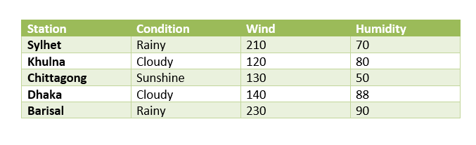

### Untidy data

We have values as column names.

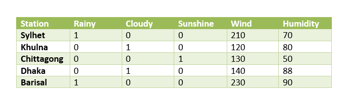

### Wide dataset vs long dataset

In wide dataset we have more columns than rows, in long dataset, we have more rows than columns

#### So among the 2 datasets that you have seen, which one is wide and which one is long?

### Using tidyr

**gather(data, key, value, …)**

**data** is a dataframe **key** is name of a new column **value** is the name of a new value column **…** is the names of the columns to gather

```r
setwd("E:/Training_S/Cleaning Data in R")
data1 = read.csv("data1.csv")
data1
```

```
##   Name Category1 Category2 Category3
## 1    A        10        18        27
## 2    B        20        32        35
## 3    C        25        45        41
```

#### Gathering columns into key-value pairs or going from wide to long using **gather**

```r
library(tidyr)
data1_long = gather(data1, categories, values, -Name)
data1_long
```

```
##   Name categories values
## 1    A  Category1     10
## 2    B  Category1     20
## 3    C  Category1     25
## 4    A  Category2     18
## 5    B  Category2     32
## 6    C  Category2     45
## 7    A  Category3     27
## 8    B  Category3     35
## 9    C  Category3     41
```

We can also write this as **gather(data, aggregated_variable, value, columns_to_gather)**

### Spreading key-value pairs or going from long to wide using **spread()**

```r
data1_wide = spread(data1_long, categories, values)
data1_wide
```

```
##   Name Category1 Category2 Category3
## 1    A        10        18        27
## 2    B        20        32        35
## 3    C        25        45        41
```

**spread(data, key, value)** data is the dataframe Key is the name of column containiing keys value is the name of the column containing values

### Separating columns

**separate(data, col, into)** **data** is which dataframe to change **col** is the name of the column to separate **into** is the character vector of new column names

Let’s have a look at a dataset where 2 persons have got 2 different type of treatments at 2 different times. The column **Time** has both year and month embedded in the column with **-** separating (or adding) the values of year and month.

```r
data2 = read.csv("data2.csv", colClasses=c("character","factor","numeric","character"))
data2
```

```
##   Name Category Value    Time
## 1    A        X    18 2010-07
## 2    B        X    32 2010-07
## 3    A        Y    45 2010-09
## 4    B        Y    42 2010-09
```

Now let’s separate **Time** column into year and month

```r
data2_separated = separate(data2, Time, c("Year", "month"))
data2_separated
```

```
##   Name Category Value Year month
## 1    A        X    18 2010    07
## 2    B        X    32 2010    07
## 3    A        Y    45 2010    09
## 4    B        Y    42 2010    09
```

**separate** assumes that we want to separate a column based on some non-alphanumeric values like empty space, period, forward slash or adash. But if our separator is something else, we can mention it in a fourth parameter in **sep=“”**.

### Unite columns

We use **unite()** function.

**unite(data, col, …)** data is the dataframe col is the new united column name … represent the column names to be united By default, the sep is **_** We can also specify the seperators as sep=“”

```r
data2_united = unite(data2_separated, Time, Year, month)
data2_united
```

```
##   Name Category Value    Time
## 1    A        X    18 2010_07
## 2    B        X    32 2010_07
## 3    A        Y    45 2010_09
## 4    B        Y    42 2010_09
```

### Converting strings to date

We have a character of dates in the vector **date_string** which **R** doesn’t recognize as date.

We can use **ymd()** function from lubridate package

```r
library(lubridate)
date_string = c("2010-01-27", "2010-12-21", "2012-09-29")
class(date_string)
```

```
## [1] "character"
```

```r
date_date = ymd(date_string)
class(date_date)
```

```
## [1] "Date"
```

```r
date_date
```

```
## [1] "2010-01-27" "2010-12-21" "2012-09-29"
```

**mdy()** function

```r
mdy("July 12, 2017")
```

```
## [1] "2017-07-12"
```

**hms()** function

```r
hms("14:34:23")
```

```
## [1] "14H 34M 23S"
```

#### Parsing date_time

```r
ymd_hms("2017/07/12 14.36.59")
```

```
## [1] "2017-07-12 14:36:59 UTC"
```

#### Working with strings with stringr package

```r
library(stringr)
```

#### Trim whitespaces in a string

```r
str_trim("    hopefully, you are enjoying this training, are you???     ")
```

```
## [1] "hopefully, you are enjoying this training, are you???"
```

#### Pad string

```r
str_pad("678", width = 6, side="left", pad="0")
```

```
## [1] "000678"
```

We can also check if a particular string is in a character vector

```r
popular_languages = c("R", "Python", "C", "Java")
r_in_popular_languages = str_detect(popular_languages, "R")
r_in_popular_languages
```

```
## [1]  TRUE FALSE FALSE FALSE
```

Suppose, C++ has replaced C in popularity and C has gone down by 5 or 6 positions. How do we update **popular_languages** vector? We use **str_replace(vector, old_value, new_value)**

```r
popular_languages = str_replace(popular_languages, "C", "C++")
popular_languages
```

```
## [1] "R"      "Python" "C++"    "Java"
```

### Missing values

This is normally represented as **NA** in excel. If we import from Excel, the missing data will be **#N/A** When we import from SAS/SPSS, the missing data will be . In some cases, it can simply be empty string

Let’s build a dataframe with some **NA** values

```r
data3 = data.frame(Type1 = c(23,34,NA,56,NA,55),
                   Type2 = c(22, 32,45,NA,76,90))
data3
```

```
##   Type1 Type2
## 1    23    22
## 2    34    32
## 3    NA    45
## 4    56    NA
## 5    NA    76
## 6    55    90
```

#### Does this data have NA values?

```r
any(is.na(data3))
```

```
## [1] TRUE
```

```r
is.na(df)
```

```
## [1] FALSE
```

#### How many NAs?

```r
sum(is.na(data3))
```

```
## [1] 3
```

#### Indices of missing value

```r
which(is.na(data3$Type1))
```

```
## [1] 3 5
```

We can also use **summary()** function to get idea about NAs.

#### Find rowws of missing data

```r
complete.cases(data3)
```

```
## [1]  TRUE  TRUE FALSE FALSE FALSE  TRUE
```

We can now subset our data to get only the rows with non-missing values

```r
data3[complete.cases(data3), ]
```

```
##   Type1 Type2
## 1    23    22
## 2    34    32
## 6    55    90
```

More comfortable though, is the use of **na.omit(dataframe)**

```r
na.omit(data3)
```

```
##   Type1 Type2
## 1    23    22
## 2    34    32
## 6    55    90
```

#### Is our data OK?

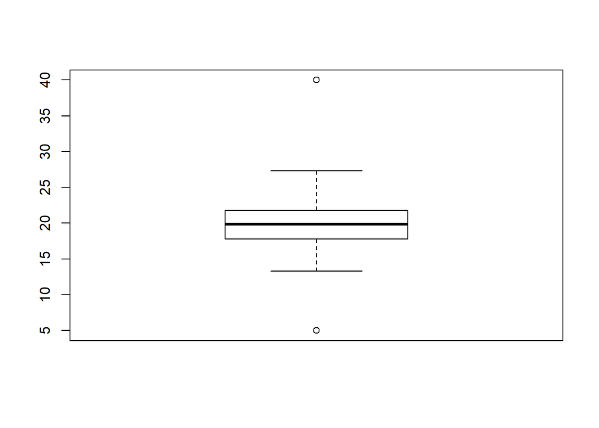

```r
set.seed(0)
data4 = c(rnorm(125, mean=20, sd=3),5, 40)

boxplot(data4)
```

We can check for errors that can come from variability in measurement, experimental error, data entry error, intentional error etc.

```r
set.seed(0)
data5 = data.frame(first=c(rnorm(24, mean=20, sd=3), 100),
                   second = rnorm(25, mean=30, sd=5),
                   third = rnorm(25, mean=40, sd=15))
summary(data5$first)
```

```
##    Min. 1st Qu.  Median    Mean 3rd Qu.    Max.
##   15.38   18.77   19.98   23.33   22.29  100.00
```

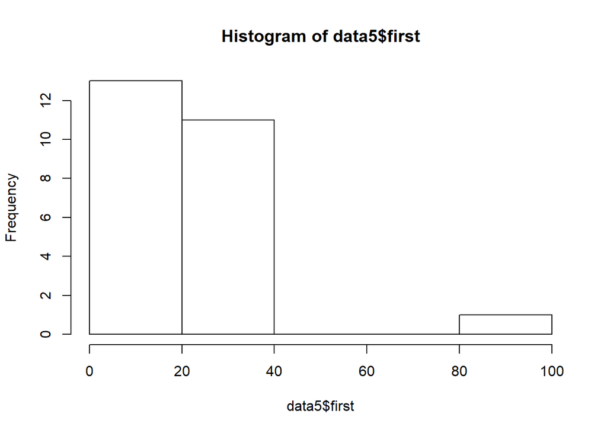

```r
hist(data5$first, breaks=5)
```

We can also look at the box plot of all the columns

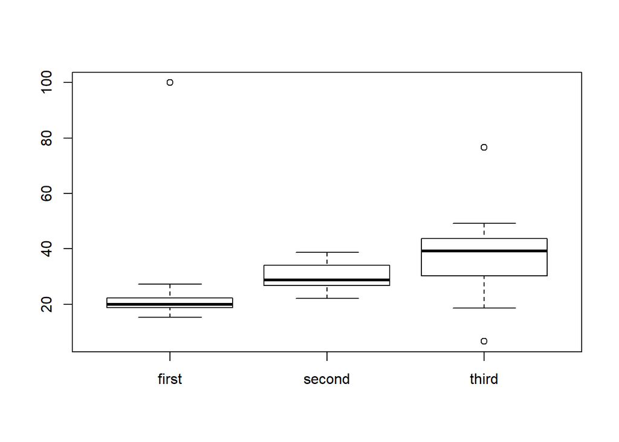

```r
boxplot(data5)
```